# Manual image metadata analysis

Set up the analysis and print out the initial dataframe.

```python
datafile = 'slide_metadata-2022-03-25.csv'
import pandas as pd
df = pd.read_csv(filepath_or_buffer=datafile)
# df = df.T.drop_duplicates(keep='last').T  # this line makes all columns strings; better to eliminate columns manually anyway
```

```python
df
```

|  | image_pathname | adapter_size | camera_type | objective_magnification | objective_name | output_resolution | project_name | slide_creationdatetime | slide_type | micrometer_per_pixel_x | micrometer_per_pixel_y | scanner_camera_type | scanner_hardware_version | bounds_height | bounds_width | mpp_x | mpp_y | objective_power | vendor |
| --- | --- | --- | --- | --- | --- | --- | --- | --- | --- | --- | --- | --- | --- | --- | --- | --- | --- | --- | --- |
| 0 | /home/weismanal/projects/idibell/repo/data/002... | 1.6 | Adimec Q-12A-180Fc | 40 | Plan-Apochromat | 82.443327 | PannoramicSlide | 07/05/2021 13:06:52 | SLIDE_TYPE_BRIGHTFIELD | 0.121267 | 0.121324 | Adimec Q-12A-180Fc | Pannoramic 1000 | 338688 | 190720 | 0.121267 | 0.121324 | 40 | mirax |
| 1 | /home/weismanal/projects/idibell/repo/data/002... | 1.6 | Adimec Q-12A-180Fc | 20 | Plan-Apochromat | 41.221663 | PannoramicSlide | 03/12/2021 17:40:45 | SLIDE_TYPE_BRIGHTFIELD | 0.242535 | 0.242647 | Adimec Q-12A-180Fc | Pannoramic 1000 | 191744 | 100608 | 0.242535 | 0.242647 | 20 | mirax |
| 2 | /home/weismanal/projects/idibell/repo/data/003... | 1.6 | Adimec Q-12A-180Fc | 20 | Plan-Apochromat | 41.221663 | PannoramicSlide | 03/12/2021 17:42:24 | SLIDE_TYPE_BRIGHTFIELD | 0.242535 | 0.242647 | Adimec Q-12A-180Fc | Pannoramic 1000 | 133120 | 100352 | 0.242535 | 0.242647 | 20 | mirax |
| 3 | /home/weismanal/projects/idibell/repo/data/003... | 1.6 | Adimec Q-12A-180Fc | 20 | Plan-Apochromat | 41.221663 | PannoramicSlide | 03/12/2021 17:47:01 | SLIDE_TYPE_BRIGHTFIELD | 0.242535 | 0.242647 | Adimec Q-12A-180Fc | Pannoramic 1000 | 122880 | 97792 | 0.242535 | 0.242647 | 20 | mirax |
| 4 | /home/weismanal/projects/idibell/repo/data/004... | 1.6 | Adimec Q-12A-180Fc | 40 | Plan-Apochromat | 63.062992 | PannoramicSlide | 28/06/2021 19:48:17 | SLIDE_TYPE_BRIGHTFIELD | 0.158309 | 0.158834 | Adimec Q-12A-180Fc | Pannoramic 1000 | 221952 | 117760 | 0.158309 | 0.158834 | 40 | mirax |
| ... | ... | ... | ... | ... | ... | ... | ... | ... | ... | ... | ... | ... | ... | ... | ... | ... | ... | ... | ... |
| 65 | /home/weismanal/projects/idibell/repo/data/Dig... | 1.6 | Adimec Q-12A-180Fc | 20 | Plan-Apochromat | NaN | Default | 21/09/2021 16:49:35 | SLIDE_TYPE_BRIGHTFIELD | 0.242535 | 0.242647 | Adimec Q-12A-180Fc | Pannoramic 1000 | 195328 | 86272 | 0.242535 | 0.242647 | 20 | mirax |
| 66 | /home/weismanal/projects/idibell/repo/data/Dig... | 1.6 | Adimec Q-12A-180Fc | 20 | Plan-Apochromat | NaN | Default | 13/09/2021 18:11:11 | SLIDE_TYPE_BRIGHTFIELD | 0.242535 | 0.242647 | Adimec Q-12A-180Fc | Pannoramic 1000 | 106240 | 50432 | 0.242535 | 0.242647 | 20 | mirax |
| 67 | /home/weismanal/projects/idibell/repo/data/Dig... | 1.6 | Adimec Q-12A-180Fc | 40 | Plan-Apochromat | 82.443327 | PannoramicSlide | 07/05/2021 12:44:45 | SLIDE_TYPE_BRIGHTFIELD | 0.121267 | 0.121324 | Adimec Q-12A-180Fc | Pannoramic 1000 | 312576 | 194304 | 0.121267 | 0.121324 | 40 | mirax |
| 68 | /home/weismanal/projects/idibell/repo/data/Dig... | 1.6 | Adimec Q-12A-180Fc | 40 | Plan-Apochromat | 82.443327 | PannoramicSlide | 07/05/2021 12:56:40 | SLIDE_TYPE_BRIGHTFIELD | 0.121267 | 0.121324 | Adimec Q-12A-180Fc | Pannoramic 1000 | 262912 | 158720 | 0.121267 | 0.121324 | 40 | mirax |
| 69 | /home/weismanal/projects/idibell/repo/data/Dig... | 1.6 | Adimec Q-12A-180Fc | 40 | Plan-Apochromat | 82.443327 | PannoramicSlide | 07/05/2021 13:14:15 | SLIDE_TYPE_BRIGHTFIELD | 0.121267 | 0.121324 | Adimec Q-12A-180Fc | Pannoramic 1000 | 394496 | 197376 | 0.121267 | 0.121324 | 40 | mirax |

70 rows × 19 columns

Delete duplicate magnification/power columns.

```python
print(df.objective_magnification.equals(df.objective_power))
df = df.drop('objective_power', axis='columns')
```

```
True
```

```python
df
```

|  | image_pathname | adapter_size | camera_type | objective_magnification | objective_name | output_resolution | project_name | slide_creationdatetime | slide_type | micrometer_per_pixel_x | micrometer_per_pixel_y | scanner_camera_type | scanner_hardware_version | bounds_height | bounds_width | mpp_x | mpp_y | vendor |
| --- | --- | --- | --- | --- | --- | --- | --- | --- | --- | --- | --- | --- | --- | --- | --- | --- | --- | --- |
| 0 | /home/weismanal/projects/idibell/repo/data/002... | 1.6 | Adimec Q-12A-180Fc | 40 | Plan-Apochromat | 82.443327 | PannoramicSlide | 07/05/2021 13:06:52 | SLIDE_TYPE_BRIGHTFIELD | 0.121267 | 0.121324 | Adimec Q-12A-180Fc | Pannoramic 1000 | 338688 | 190720 | 0.121267 | 0.121324 | mirax |
| 1 | /home/weismanal/projects/idibell/repo/data/002... | 1.6 | Adimec Q-12A-180Fc | 20 | Plan-Apochromat | 41.221663 | PannoramicSlide | 03/12/2021 17:40:45 | SLIDE_TYPE_BRIGHTFIELD | 0.242535 | 0.242647 | Adimec Q-12A-180Fc | Pannoramic 1000 | 191744 | 100608 | 0.242535 | 0.242647 | mirax |
| 2 | /home/weismanal/projects/idibell/repo/data/003... | 1.6 | Adimec Q-12A-180Fc | 20 | Plan-Apochromat | 41.221663 | PannoramicSlide | 03/12/2021 17:42:24 | SLIDE_TYPE_BRIGHTFIELD | 0.242535 | 0.242647 | Adimec Q-12A-180Fc | Pannoramic 1000 | 133120 | 100352 | 0.242535 | 0.242647 | mirax |
| 3 | /home/weismanal/projects/idibell/repo/data/003... | 1.6 | Adimec Q-12A-180Fc | 20 | Plan-Apochromat | 41.221663 | PannoramicSlide | 03/12/2021 17:47:01 | SLIDE_TYPE_BRIGHTFIELD | 0.242535 | 0.242647 | Adimec Q-12A-180Fc | Pannoramic 1000 | 122880 | 97792 | 0.242535 | 0.242647 | mirax |
| 4 | /home/weismanal/projects/idibell/repo/data/004... | 1.6 | Adimec Q-12A-180Fc | 40 | Plan-Apochromat | 63.062992 | PannoramicSlide | 28/06/2021 19:48:17 | SLIDE_TYPE_BRIGHTFIELD | 0.158309 | 0.158834 | Adimec Q-12A-180Fc | Pannoramic 1000 | 221952 | 117760 | 0.158309 | 0.158834 | mirax |
| ... | ... | ... | ... | ... | ... | ... | ... | ... | ... | ... | ... | ... | ... | ... | ... | ... | ... | ... |
| 65 | /home/weismanal/projects/idibell/repo/data/Dig... | 1.6 | Adimec Q-12A-180Fc | 20 | Plan-Apochromat | NaN | Default | 21/09/2021 16:49:35 | SLIDE_TYPE_BRIGHTFIELD | 0.242535 | 0.242647 | Adimec Q-12A-180Fc | Pannoramic 1000 | 195328 | 86272 | 0.242535 | 0.242647 | mirax |
| 66 | /home/weismanal/projects/idibell/repo/data/Dig... | 1.6 | Adimec Q-12A-180Fc | 20 | Plan-Apochromat | NaN | Default | 13/09/2021 18:11:11 | SLIDE_TYPE_BRIGHTFIELD | 0.242535 | 0.242647 | Adimec Q-12A-180Fc | Pannoramic 1000 | 106240 | 50432 | 0.242535 | 0.242647 | mirax |
| 67 | /home/weismanal/projects/idibell/repo/data/Dig... | 1.6 | Adimec Q-12A-180Fc | 40 | Plan-Apochromat | 82.443327 | PannoramicSlide | 07/05/2021 12:44:45 | SLIDE_TYPE_BRIGHTFIELD | 0.121267 | 0.121324 | Adimec Q-12A-180Fc | Pannoramic 1000 | 312576 | 194304 | 0.121267 | 0.121324 | mirax |
| 68 | /home/weismanal/projects/idibell/repo/data/Dig... | 1.6 | Adimec Q-12A-180Fc | 40 | Plan-Apochromat | 82.443327 | PannoramicSlide | 07/05/2021 12:56:40 | SLIDE_TYPE_BRIGHTFIELD | 0.121267 | 0.121324 | Adimec Q-12A-180Fc | Pannoramic 1000 | 262912 | 158720 | 0.121267 | 0.121324 | mirax |
| 69 | /home/weismanal/projects/idibell/repo/data/Dig... | 1.6 | Adimec Q-12A-180Fc | 40 | Plan-Apochromat | 82.443327 | PannoramicSlide | 07/05/2021 13:14:15 | SLIDE_TYPE_BRIGHTFIELD | 0.121267 | 0.121324 | Adimec Q-12A-180Fc | Pannoramic 1000 | 394496 | 197376 | 0.121267 | 0.121324 | mirax |

70 rows × 18 columns

Delete duplicate camera type columns.

```python
print(df.scanner_camera_type.equals(df.camera_type))
df = df.drop('camera_type', axis='columns')
```

```
True
```

```python
df
```

|  | image_pathname | adapter_size | objective_magnification | objective_name | output_resolution | project_name | slide_creationdatetime | slide_type | micrometer_per_pixel_x | micrometer_per_pixel_y | scanner_camera_type | scanner_hardware_version | bounds_height | bounds_width | mpp_x | mpp_y | vendor |
| --- | --- | --- | --- | --- | --- | --- | --- | --- | --- | --- | --- | --- | --- | --- | --- | --- | --- |
| 0 | /home/weismanal/projects/idibell/repo/data/002... | 1.6 | 40 | Plan-Apochromat | 82.443327 | PannoramicSlide | 07/05/2021 13:06:52 | SLIDE_TYPE_BRIGHTFIELD | 0.121267 | 0.121324 | Adimec Q-12A-180Fc | Pannoramic 1000 | 338688 | 190720 | 0.121267 | 0.121324 | mirax |
| 1 | /home/weismanal/projects/idibell/repo/data/002... | 1.6 | 20 | Plan-Apochromat | 41.221663 | PannoramicSlide | 03/12/2021 17:40:45 | SLIDE_TYPE_BRIGHTFIELD | 0.242535 | 0.242647 | Adimec Q-12A-180Fc | Pannoramic 1000 | 191744 | 100608 | 0.242535 | 0.242647 | mirax |
| 2 | /home/weismanal/projects/idibell/repo/data/003... | 1.6 | 20 | Plan-Apochromat | 41.221663 | PannoramicSlide | 03/12/2021 17:42:24 | SLIDE_TYPE_BRIGHTFIELD | 0.242535 | 0.242647 | Adimec Q-12A-180Fc | Pannoramic 1000 | 133120 | 100352 | 0.242535 | 0.242647 | mirax |
| 3 | /home/weismanal/projects/idibell/repo/data/003... | 1.6 | 20 | Plan-Apochromat | 41.221663 | PannoramicSlide | 03/12/2021 17:47:01 | SLIDE_TYPE_BRIGHTFIELD | 0.242535 | 0.242647 | Adimec Q-12A-180Fc | Pannoramic 1000 | 122880 | 97792 | 0.242535 | 0.242647 | mirax |
| 4 | /home/weismanal/projects/idibell/repo/data/004... | 1.6 | 40 | Plan-Apochromat | 63.062992 | PannoramicSlide | 28/06/2021 19:48:17 | SLIDE_TYPE_BRIGHTFIELD | 0.158309 | 0.158834 | Adimec Q-12A-180Fc | Pannoramic 1000 | 221952 | 117760 | 0.158309 | 0.158834 | mirax |
| ... | ... | ... | ... | ... | ... | ... | ... | ... | ... | ... | ... | ... | ... | ... | ... | ... | ... |
| 65 | /home/weismanal/projects/idibell/repo/data/Dig... | 1.6 | 20 | Plan-Apochromat | NaN | Default | 21/09/2021 16:49:35 | SLIDE_TYPE_BRIGHTFIELD | 0.242535 | 0.242647 | Adimec Q-12A-180Fc | Pannoramic 1000 | 195328 | 86272 | 0.242535 | 0.242647 | mirax |
| 66 | /home/weismanal/projects/idibell/repo/data/Dig... | 1.6 | 20 | Plan-Apochromat | NaN | Default | 13/09/2021 18:11:11 | SLIDE_TYPE_BRIGHTFIELD | 0.242535 | 0.242647 | Adimec Q-12A-180Fc | Pannoramic 1000 | 106240 | 50432 | 0.242535 | 0.242647 | mirax |
| 67 | /home/weismanal/projects/idibell/repo/data/Dig... | 1.6 | 40 | Plan-Apochromat | 82.443327 | PannoramicSlide | 07/05/2021 12:44:45 | SLIDE_TYPE_BRIGHTFIELD | 0.121267 | 0.121324 | Adimec Q-12A-180Fc | Pannoramic 1000 | 312576 | 194304 | 0.121267 | 0.121324 | mirax |
| 68 | /home/weismanal/projects/idibell/repo/data/Dig... | 1.6 | 40 | Plan-Apochromat | 82.443327 | PannoramicSlide | 07/05/2021 12:56:40 | SLIDE_TYPE_BRIGHTFIELD | 0.121267 | 0.121324 | Adimec Q-12A-180Fc | Pannoramic 1000 | 262912 | 158720 | 0.121267 | 0.121324 | mirax |
| 69 | /home/weismanal/projects/idibell/repo/data/Dig... | 1.6 | 40 | Plan-Apochromat | 82.443327 | PannoramicSlide | 07/05/2021 13:14:15 | SLIDE_TYPE_BRIGHTFIELD | 0.121267 | 0.121324 | Adimec Q-12A-180Fc | Pannoramic 1000 | 394496 | 197376 | 0.121267 | 0.121324 | mirax |

70 rows × 17 columns

Delete duplicate microns per pixel x columns.

```python
print(df.mpp_x.equals(df.micrometer_per_pixel_x))
df = df.drop('micrometer_per_pixel_x', axis='columns')
```

```
True
```

```python
df
```

|  | image_pathname | adapter_size | objective_magnification | objective_name | output_resolution | project_name | slide_creationdatetime | slide_type | micrometer_per_pixel_y | scanner_camera_type | scanner_hardware_version | bounds_height | bounds_width | mpp_x | mpp_y | vendor |
| --- | --- | --- | --- | --- | --- | --- | --- | --- | --- | --- | --- | --- | --- | --- | --- | --- |
| 0 | /home/weismanal/projects/idibell/repo/data/002... | 1.6 | 40 | Plan-Apochromat | 82.443327 | PannoramicSlide | 07/05/2021 13:06:52 | SLIDE_TYPE_BRIGHTFIELD | 0.121324 | Adimec Q-12A-180Fc | Pannoramic 1000 | 338688 | 190720 | 0.121267 | 0.121324 | mirax |
| 1 | /home/weismanal/projects/idibell/repo/data/002... | 1.6 | 20 | Plan-Apochromat | 41.221663 | PannoramicSlide | 03/12/2021 17:40:45 | SLIDE_TYPE_BRIGHTFIELD | 0.242647 | Adimec Q-12A-180Fc | Pannoramic 1000 | 191744 | 100608 | 0.242535 | 0.242647 | mirax |
| 2 | /home/weismanal/projects/idibell/repo/data/003... | 1.6 | 20 | Plan-Apochromat | 41.221663 | PannoramicSlide | 03/12/2021 17:42:24 | SLIDE_TYPE_BRIGHTFIELD | 0.242647 | Adimec Q-12A-180Fc | Pannoramic 1000 | 133120 | 100352 | 0.242535 | 0.242647 | mirax |
| 3 | /home/weismanal/projects/idibell/repo/data/003... | 1.6 | 20 | Plan-Apochromat | 41.221663 | PannoramicSlide | 03/12/2021 17:47:01 | SLIDE_TYPE_BRIGHTFIELD | 0.242647 | Adimec Q-12A-180Fc | Pannoramic 1000 | 122880 | 97792 | 0.242535 | 0.242647 | mirax |
| 4 | /home/weismanal/projects/idibell/repo/data/004... | 1.6 | 40 | Plan-Apochromat | 63.062992 | PannoramicSlide | 28/06/2021 19:48:17 | SLIDE_TYPE_BRIGHTFIELD | 0.158834 | Adimec Q-12A-180Fc | Pannoramic 1000 | 221952 | 117760 | 0.158309 | 0.158834 | mirax |
| ... | ... | ... | ... | ... | ... | ... | ... | ... | ... | ... | ... | ... | ... | ... | ... | ... |
| 65 | /home/weismanal/projects/idibell/repo/data/Dig... | 1.6 | 20 | Plan-Apochromat | NaN | Default | 21/09/2021 16:49:35 | SLIDE_TYPE_BRIGHTFIELD | 0.242647 | Adimec Q-12A-180Fc | Pannoramic 1000 | 195328 | 86272 | 0.242535 | 0.242647 | mirax |
| 66 | /home/weismanal/projects/idibell/repo/data/Dig... | 1.6 | 20 | Plan-Apochromat | NaN | Default | 13/09/2021 18:11:11 | SLIDE_TYPE_BRIGHTFIELD | 0.242647 | Adimec Q-12A-180Fc | Pannoramic 1000 | 106240 | 50432 | 0.242535 | 0.242647 | mirax |
| 67 | /home/weismanal/projects/idibell/repo/data/Dig... | 1.6 | 40 | Plan-Apochromat | 82.443327 | PannoramicSlide | 07/05/2021 12:44:45 | SLIDE_TYPE_BRIGHTFIELD | 0.121324 | Adimec Q-12A-180Fc | Pannoramic 1000 | 312576 | 194304 | 0.121267 | 0.121324 | mirax |
| 68 | /home/weismanal/projects/idibell/repo/data/Dig... | 1.6 | 40 | Plan-Apochromat | 82.443327 | PannoramicSlide | 07/05/2021 12:56:40 | SLIDE_TYPE_BRIGHTFIELD | 0.121324 | Adimec Q-12A-180Fc | Pannoramic 1000 | 262912 | 158720 | 0.121267 | 0.121324 | mirax |
| 69 | /home/weismanal/projects/idibell/repo/data/Dig... | 1.6 | 40 | Plan-Apochromat | 82.443327 | PannoramicSlide | 07/05/2021 13:14:15 | SLIDE_TYPE_BRIGHTFIELD | 0.121324 | Adimec Q-12A-180Fc | Pannoramic 1000 | 394496 | 197376 | 0.121267 | 0.121324 | mirax |

70 rows × 16 columns

Delete duplicate microns per pixel y columns.

```python
print(df.mpp_y.equals(df.micrometer_per_pixel_y))
print((df.micrometer_per_pixel_y - df.mpp_y).abs().max())
df = df.drop('micrometer_per_pixel_y', axis='columns')
```

```
False
8.326672684688674e-17
```

```python
df
```

|  | image_pathname | adapter_size | objective_magnification | objective_name | output_resolution | project_name | slide_creationdatetime | slide_type | scanner_camera_type | scanner_hardware_version | bounds_height | bounds_width | mpp_x | mpp_y | vendor |
| --- | --- | --- | --- | --- | --- | --- | --- | --- | --- | --- | --- | --- | --- | --- | --- |
| 0 | /home/weismanal/projects/idibell/repo/data/002... | 1.6 | 40 | Plan-Apochromat | 82.443327 | PannoramicSlide | 07/05/2021 13:06:52 | SLIDE_TYPE_BRIGHTFIELD | Adimec Q-12A-180Fc | Pannoramic 1000 | 338688 | 190720 | 0.121267 | 0.121324 | mirax |
| 1 | /home/weismanal/projects/idibell/repo/data/002... | 1.6 | 20 | Plan-Apochromat | 41.221663 | PannoramicSlide | 03/12/2021 17:40:45 | SLIDE_TYPE_BRIGHTFIELD | Adimec Q-12A-180Fc | Pannoramic 1000 | 191744 | 100608 | 0.242535 | 0.242647 | mirax |
| 2 | /home/weismanal/projects/idibell/repo/data/003... | 1.6 | 20 | Plan-Apochromat | 41.221663 | PannoramicSlide | 03/12/2021 17:42:24 | SLIDE_TYPE_BRIGHTFIELD | Adimec Q-12A-180Fc | Pannoramic 1000 | 133120 | 100352 | 0.242535 | 0.242647 | mirax |
| 3 | /home/weismanal/projects/idibell/repo/data/003... | 1.6 | 20 | Plan-Apochromat | 41.221663 | PannoramicSlide | 03/12/2021 17:47:01 | SLIDE_TYPE_BRIGHTFIELD | Adimec Q-12A-180Fc | Pannoramic 1000 | 122880 | 97792 | 0.242535 | 0.242647 | mirax |
| 4 | /home/weismanal/projects/idibell/repo/data/004... | 1.6 | 40 | Plan-Apochromat | 63.062992 | PannoramicSlide | 28/06/2021 19:48:17 | SLIDE_TYPE_BRIGHTFIELD | Adimec Q-12A-180Fc | Pannoramic 1000 | 221952 | 117760 | 0.158309 | 0.158834 | mirax |
| ... | ... | ... | ... | ... | ... | ... | ... | ... | ... | ... | ... | ... | ... | ... | ... |
| 65 | /home/weismanal/projects/idibell/repo/data/Dig... | 1.6 | 20 | Plan-Apochromat | NaN | Default | 21/09/2021 16:49:35 | SLIDE_TYPE_BRIGHTFIELD | Adimec Q-12A-180Fc | Pannoramic 1000 | 195328 | 86272 | 0.242535 | 0.242647 | mirax |
| 66 | /home/weismanal/projects/idibell/repo/data/Dig... | 1.6 | 20 | Plan-Apochromat | NaN | Default | 13/09/2021 18:11:11 | SLIDE_TYPE_BRIGHTFIELD | Adimec Q-12A-180Fc | Pannoramic 1000 | 106240 | 50432 | 0.242535 | 0.242647 | mirax |
| 67 | /home/weismanal/projects/idibell/repo/data/Dig... | 1.6 | 40 | Plan-Apochromat | 82.443327 | PannoramicSlide | 07/05/2021 12:44:45 | SLIDE_TYPE_BRIGHTFIELD | Adimec Q-12A-180Fc | Pannoramic 1000 | 312576 | 194304 | 0.121267 | 0.121324 | mirax |
| 68 | /home/weismanal/projects/idibell/repo/data/Dig... | 1.6 | 40 | Plan-Apochromat | 82.443327 | PannoramicSlide | 07/05/2021 12:56:40 | SLIDE_TYPE_BRIGHTFIELD | Adimec Q-12A-180Fc | Pannoramic 1000 | 262912 | 158720 | 0.121267 | 0.121324 | mirax |
| 69 | /home/weismanal/projects/idibell/repo/data/Dig... | 1.6 | 40 | Plan-Apochromat | 82.443327 | PannoramicSlide | 07/05/2021 13:14:15 | SLIDE_TYPE_BRIGHTFIELD | Adimec Q-12A-180Fc | Pannoramic 1000 | 394496 | 197376 | 0.121267 | 0.121324 | mirax |

70 rows × 15 columns

Print out general dataframe information, showing that the `output_resolution` column has many null entries.

```python
df.info()
```

```
<class 'pandas.core.frame.DataFrame'>
RangeIndex: 70 entries, 0 to 69
Data columns (total 15 columns):
 #   Column                    Non-Null Count  Dtype
---  ------                    --------------  -----
 0   image_pathname            70 non-null     object
 1   adapter_size              70 non-null     float64
 2   objective_magnification   70 non-null     int64
 3   objective_name            70 non-null     object
 4   output_resolution         45 non-null     float64
 5   project_name              70 non-null     object
 6   slide_creationdatetime    70 non-null     object
 7   slide_type                70 non-null     object
 8   scanner_camera_type       70 non-null     object
 9   scanner_hardware_version  70 non-null     object
 10  bounds_height             70 non-null     int64
 11  bounds_width              70 non-null     int64
 12  mpp_x                     70 non-null     float64
 13  mpp_y                     70 non-null     float64
 14  vendor                    70 non-null     object
dtypes: float64(4), int64(3), object(8)
memory usage: 8.3+ KB
```

Calculate the output resolution for the rest of the columns, checking that the new values are equal to the old ones that exist, and replace the `output_resolution` column with this.

```python
actual_magnification = 10 / ((df.mpp_x + df.mpp_y) / 2)
print((actual_magnification - df.output_resolution).abs().max())
df.output_resolution = actual_magnification
```

```
1.0658141036401503e-13
```

```python
df
```

|  | image_pathname | adapter_size | objective_magnification | objective_name | output_resolution | project_name | slide_creationdatetime | slide_type | scanner_camera_type | scanner_hardware_version | bounds_height | bounds_width | mpp_x | mpp_y | vendor |
| --- | --- | --- | --- | --- | --- | --- | --- | --- | --- | --- | --- | --- | --- | --- | --- |
| 0 | /home/weismanal/projects/idibell/repo/data/002... | 1.6 | 40 | Plan-Apochromat | 82.443327 | PannoramicSlide | 07/05/2021 13:06:52 | SLIDE_TYPE_BRIGHTFIELD | Adimec Q-12A-180Fc | Pannoramic 1000 | 338688 | 190720 | 0.121267 | 0.121324 | mirax |
| 1 | /home/weismanal/projects/idibell/repo/data/002... | 1.6 | 20 | Plan-Apochromat | 41.221663 | PannoramicSlide | 03/12/2021 17:40:45 | SLIDE_TYPE_BRIGHTFIELD | Adimec Q-12A-180Fc | Pannoramic 1000 | 191744 | 100608 | 0.242535 | 0.242647 | mirax |
| 2 | /home/weismanal/projects/idibell/repo/data/003... | 1.6 | 20 | Plan-Apochromat | 41.221663 | PannoramicSlide | 03/12/2021 17:42:24 | SLIDE_TYPE_BRIGHTFIELD | Adimec Q-12A-180Fc | Pannoramic 1000 | 133120 | 100352 | 0.242535 | 0.242647 | mirax |
| 3 | /home/weismanal/projects/idibell/repo/data/003... | 1.6 | 20 | Plan-Apochromat | 41.221663 | PannoramicSlide | 03/12/2021 17:47:01 | SLIDE_TYPE_BRIGHTFIELD | Adimec Q-12A-180Fc | Pannoramic 1000 | 122880 | 97792 | 0.242535 | 0.242647 | mirax |
| 4 | /home/weismanal/projects/idibell/repo/data/004... | 1.6 | 40 | Plan-Apochromat | 63.062992 | PannoramicSlide | 28/06/2021 19:48:17 | SLIDE_TYPE_BRIGHTFIELD | Adimec Q-12A-180Fc | Pannoramic 1000 | 221952 | 117760 | 0.158309 | 0.158834 | mirax |
| ... | ... | ... | ... | ... | ... | ... | ... | ... | ... | ... | ... | ... | ... | ... | ... |
| 65 | /home/weismanal/projects/idibell/repo/data/Dig... | 1.6 | 20 | Plan-Apochromat | 41.221663 | Default | 21/09/2021 16:49:35 | SLIDE_TYPE_BRIGHTFIELD | Adimec Q-12A-180Fc | Pannoramic 1000 | 195328 | 86272 | 0.242535 | 0.242647 | mirax |
| 66 | /home/weismanal/projects/idibell/repo/data/Dig... | 1.6 | 20 | Plan-Apochromat | 41.221663 | Default | 13/09/2021 18:11:11 | SLIDE_TYPE_BRIGHTFIELD | Adimec Q-12A-180Fc | Pannoramic 1000 | 106240 | 50432 | 0.242535 | 0.242647 | mirax |
| 67 | /home/weismanal/projects/idibell/repo/data/Dig... | 1.6 | 40 | Plan-Apochromat | 82.443327 | PannoramicSlide | 07/05/2021 12:44:45 | SLIDE_TYPE_BRIGHTFIELD | Adimec Q-12A-180Fc | Pannoramic 1000 | 312576 | 194304 | 0.121267 | 0.121324 | mirax |
| 68 | /home/weismanal/projects/idibell/repo/data/Dig... | 1.6 | 40 | Plan-Apochromat | 82.443327 | PannoramicSlide | 07/05/2021 12:56:40 | SLIDE_TYPE_BRIGHTFIELD | Adimec Q-12A-180Fc | Pannoramic 1000 | 262912 | 158720 | 0.121267 | 0.121324 | mirax |
| 69 | /home/weismanal/projects/idibell/repo/data/Dig... | 1.6 | 40 | Plan-Apochromat | 82.443327 | PannoramicSlide | 07/05/2021 13:14:15 | SLIDE_TYPE_BRIGHTFIELD | Adimec Q-12A-180Fc | Pannoramic 1000 | 394496 | 197376 | 0.121267 | 0.121324 | mirax |

70 rows × 15 columns

Show that there are no more null values in the `output_resolution` column.

```python
df.info()
```

```
<class 'pandas.core.frame.DataFrame'>
RangeIndex: 70 entries, 0 to 69
Data columns (total 15 columns):
 #   Column                    Non-Null Count  Dtype
---  ------                    --------------  -----
 0   image_pathname            70 non-null     object
 1   adapter_size              70 non-null     float64
 2   objective_magnification   70 non-null     int64
 3   objective_name            70 non-null     object
 4   output_resolution         70 non-null     float64
 5   project_name              70 non-null     object
 6   slide_creationdatetime    70 non-null     object
 7   slide_type                70 non-null     object
 8   scanner_camera_type       70 non-null     object
 9   scanner_hardware_version  70 non-null     object
 10  bounds_height             70 non-null     int64
 11  bounds_width              70 non-null     int64
 12  mpp_x                     70 non-null     float64
 13  mpp_y                     70 non-null     float64
 14  vendor                    70 non-null     object
dtypes: float64(4), int64(3), object(8)
memory usage: 8.3+ KB
```

Find the columns that have only a single unique value, printing this value for these columns.

```python
srs_nunique = df.nunique()
unique_cols = srs_nunique[srs_nunique==1].index.to_list()
print(df.loc[0, unique_cols])
```

```
adapter_size                                   1.6
objective_name                     Plan-Apochromat
slide_type                  SLIDE_TYPE_BRIGHTFIELD
scanner_camera_type             Adimec Q-12A-180Fc
scanner_hardware_version           Pannoramic 1000
vendor                                       mirax
Name: 0, dtype: object
```

Drop these columns from the main dataframe; all information is printed in the above cell.

```python
df = df.drop(unique_cols, axis='columns')
```

```python
df
```

|  | image_pathname | objective_magnification | output_resolution | project_name | slide_creationdatetime | bounds_height | bounds_width | mpp_x | mpp_y |
| --- | --- | --- | --- | --- | --- | --- | --- | --- | --- |
| 0 | /home/weismanal/projects/idibell/repo/data/002... | 40 | 82.443327 | PannoramicSlide | 07/05/2021 13:06:52 | 338688 | 190720 | 0.121267 | 0.121324 |
| 1 | /home/weismanal/projects/idibell/repo/data/002... | 20 | 41.221663 | PannoramicSlide | 03/12/2021 17:40:45 | 191744 | 100608 | 0.242535 | 0.242647 |
| 2 | /home/weismanal/projects/idibell/repo/data/003... | 20 | 41.221663 | PannoramicSlide | 03/12/2021 17:42:24 | 133120 | 100352 | 0.242535 | 0.242647 |
| 3 | /home/weismanal/projects/idibell/repo/data/003... | 20 | 41.221663 | PannoramicSlide | 03/12/2021 17:47:01 | 122880 | 97792 | 0.242535 | 0.242647 |
| 4 | /home/weismanal/projects/idibell/repo/data/004... | 40 | 63.062992 | PannoramicSlide | 28/06/2021 19:48:17 | 221952 | 117760 | 0.158309 | 0.158834 |
| ... | ... | ... | ... | ... | ... | ... | ... | ... | ... |
| 65 | /home/weismanal/projects/idibell/repo/data/Dig... | 20 | 41.221663 | Default | 21/09/2021 16:49:35 | 195328 | 86272 | 0.242535 | 0.242647 |
| 66 | /home/weismanal/projects/idibell/repo/data/Dig... | 20 | 41.221663 | Default | 13/09/2021 18:11:11 | 106240 | 50432 | 0.242535 | 0.242647 |
| 67 | /home/weismanal/projects/idibell/repo/data/Dig... | 40 | 82.443327 | PannoramicSlide | 07/05/2021 12:44:45 | 312576 | 194304 | 0.121267 | 0.121324 |
| 68 | /home/weismanal/projects/idibell/repo/data/Dig... | 40 | 82.443327 | PannoramicSlide | 07/05/2021 12:56:40 | 262912 | 158720 | 0.121267 | 0.121324 |
| 69 | /home/weismanal/projects/idibell/repo/data/Dig... | 40 | 82.443327 | PannoramicSlide | 07/05/2021 13:14:15 | 394496 | 197376 | 0.121267 | 0.121324 |

70 rows × 9 columns

Add an area (in units of square pixels) column.

```python
df['area_sq_px'] = df.bounds_height * df.bounds_width
df
```

|  | image_pathname | objective_magnification | output_resolution | project_name | slide_creationdatetime | bounds_height | bounds_width | mpp_x | mpp_y | area_sq_px |
| --- | --- | --- | --- | --- | --- | --- | --- | --- | --- | --- |
| 0 | /home/weismanal/projects/idibell/repo/data/002... | 40 | 82.443327 | PannoramicSlide | 07/05/2021 13:06:52 | 338688 | 190720 | 0.121267 | 0.121324 | 64594575360 |
| 1 | /home/weismanal/projects/idibell/repo/data/002... | 20 | 41.221663 | PannoramicSlide | 03/12/2021 17:40:45 | 191744 | 100608 | 0.242535 | 0.242647 | 19290980352 |
| 2 | /home/weismanal/projects/idibell/repo/data/003... | 20 | 41.221663 | PannoramicSlide | 03/12/2021 17:42:24 | 133120 | 100352 | 0.242535 | 0.242647 | 13358858240 |
| 3 | /home/weismanal/projects/idibell/repo/data/003... | 20 | 41.221663 | PannoramicSlide | 03/12/2021 17:47:01 | 122880 | 97792 | 0.242535 | 0.242647 | 12016680960 |
| 4 | /home/weismanal/projects/idibell/repo/data/004... | 40 | 63.062992 | PannoramicSlide | 28/06/2021 19:48:17 | 221952 | 117760 | 0.158309 | 0.158834 | 26137067520 |
| ... | ... | ... | ... | ... | ... | ... | ... | ... | ... | ... |
| 65 | /home/weismanal/projects/idibell/repo/data/Dig... | 20 | 41.221663 | Default | 21/09/2021 16:49:35 | 195328 | 86272 | 0.242535 | 0.242647 | 16851337216 |
| 66 | /home/weismanal/projects/idibell/repo/data/Dig... | 20 | 41.221663 | Default | 13/09/2021 18:11:11 | 106240 | 50432 | 0.242535 | 0.242647 | 5357895680 |
| 67 | /home/weismanal/projects/idibell/repo/data/Dig... | 40 | 82.443327 | PannoramicSlide | 07/05/2021 12:44:45 | 312576 | 194304 | 0.121267 | 0.121324 | 60734767104 |
| 68 | /home/weismanal/projects/idibell/repo/data/Dig... | 40 | 82.443327 | PannoramicSlide | 07/05/2021 12:56:40 | 262912 | 158720 | 0.121267 | 0.121324 | 41729392640 |
| 69 | /home/weismanal/projects/idibell/repo/data/Dig... | 40 | 82.443327 | PannoramicSlide | 07/05/2021 13:14:15 | 394496 | 197376 | 0.121267 | 0.121324 | 77864042496 |

70 rows × 10 columns

Use these areas to detect what *might* be duplicate images.

```python
areas_duped = df.area_sq_px.loc[df.area_sq_px.duplicated()].to_list()
duped_images = df.loc[df.area_sq_px.apply(lambda x: x in areas_duped)]
duped_images
```

|  | image_pathname | objective_magnification | output_resolution | project_name | slide_creationdatetime | bounds_height | bounds_width | mpp_x | mpp_y | area_sq_px |
| --- | --- | --- | --- | --- | --- | --- | --- | --- | --- | --- |
| 32 | /home/weismanal/projects/idibell/repo/data/Dig... | 20 | 41.221663 | Default | 11/01/2022 21:40:12 | 166400 | 100352 | 0.242535 | 0.242647 | 16698572800 |
| 45 | /home/weismanal/projects/idibell/repo/data/Dig... | 20 | 41.221663 | Default | 25/08/2021 17:37:21 | 166400 | 100352 | 0.242535 | 0.242647 | 16698572800 |

Note, from the above `duped_images` dataframe, even though `DigitalSlide_B1M_18S_1.mrxs` and `DigitalSlide_B2M_4S_1_20210826184014839.mrxs` have the exact same sizes and other properties in common, they are completely different images, as confirmed from looking at the images themselves in Case Viewer.

Print the number of unique entries in each column.

```python
df.nunique()
```

```
image_pathname             70
objective_magnification     2
output_resolution           3
project_name                2
slide_creationdatetime     70
bounds_height              59
bounds_width               44
mpp_x                       3
mpp_y                       3
area_sq_px                 69
dtype: int64
```

Calculate some descriptive statistics on the numerical columns.

```python
df.describe()
```

|  | objective_magnification | output_resolution | bounds_height | bounds_width | mpp_x | mpp_y | area_sq_px |
| --- | --- | --- | --- | --- | --- | --- | --- |
| count | 70.000000 | 70.000000 | 70.000000 | 70.000000 | 70.000000 | 70.000000 | 7.000000e+01 |
| mean | 27.142857 | 51.237033 | 202795.885714 | 115935.085714 | 0.208221 | 0.208427 | 2.545064e+10 |
| std | 9.652342 | 14.587076 | 66801.861166 | 34754.480589 | 0.047522 | 0.047427 | 1.637925e+10 |
| min | 20.000000 | 41.221663 | 72960.000000 | 44800.000000 | 0.121267 | 0.121324 | 5.285806e+09 |
| 25% | 20.000000 | 41.221663 | 166400.000000 | 97536.000000 | 0.158309 | 0.158834 | 1.520583e+10 |
| 50% | 20.000000 | 41.221663 | 190208.000000 | 100352.000000 | 0.242535 | 0.242647 | 1.904630e+10 |
| 75% | 40.000000 | 63.062992 | 226368.000000 | 145920.000000 | 0.242535 | 0.242647 | 3.417702e+10 |
| max | 40.000000 | 82.443327 | 394496.000000 | 197376.000000 | 0.242535 | 0.242647 | 7.786404e+10 |

Plot histograms for the numerical columns.

```
array([[<AxesSubplot:title={'center':'objective_magnification'}>,
        <AxesSubplot:title={'center':'output_resolution'}>,
        <AxesSubplot:title={'center':'bounds_height'}>],
       [<AxesSubplot:title={'center':'bounds_width'}>,
        <AxesSubplot:title={'center':'mpp_x'}>,
        <AxesSubplot:title={'center':'mpp_y'}>],
       [<AxesSubplot:title={'center':'area_sq_px'}>, <AxesSubplot:>,
        <AxesSubplot:>]], dtype=object)
```

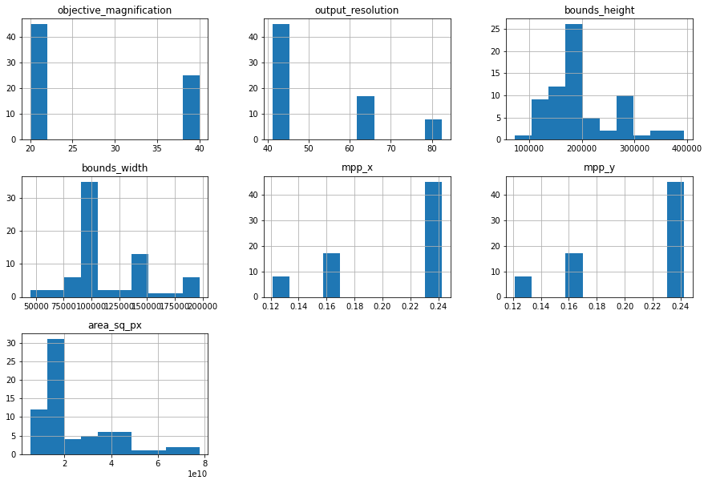

```python
df.hist(figsize=(15, 10))
```

Print the actual unique values in all the columns, not just the numerical ones.

```python
for srs in df:
    print('{}:'.format(srs))
    print(df[srs].value_counts())
    print('')
```

```
image_pathname:
/home/weismanal/projects/idibell/repo/data/0029468706.mrxs                                 1
/home/weismanal/projects/idibell/repo/data/DigitalSlide_B2M_3S_1_20210826183921228.mrxs    1
/home/weismanal/projects/idibell/repo/data/DigitalSlide_B2M_9S_1_20210826184515465.mrxs    1
/home/weismanal/projects/idibell/repo/data/DigitalSlide_B2M_8S_1_20210826184401956.mrxs    1
/home/weismanal/projects/idibell/repo/data/DigitalSlide_B2M_7S_1_20210826184304020.mrxs    1
                                                                                          ..
/home/weismanal/projects/idibell/repo/data/DigitalSlide_B1M_14S_1.mrxs                     1
/home/weismanal/projects/idibell/repo/data/DigitalSlide_B1M_15S_1.mrxs                     1
/home/weismanal/projects/idibell/repo/data/DigitalSlide_B1M_16S_1.mrxs                     1
/home/weismanal/projects/idibell/repo/data/DigitalSlide_B1M_18S_1.mrxs                     1
/home/weismanal/projects/idibell/repo/data/DigitalSlide_E6M_20S_1.mrxs                     1
Name: image_pathname, Length: 70, dtype: int64

objective_magnification:
20    45
40    25
Name: objective_magnification, dtype: int64

output_resolution:
41.221663    45
63.062992    17
82.443327     8
Name: output_resolution, dtype: int64

project_name:
PannoramicSlide    45
Default            25
Name: project_name, dtype: int64

slide_creationdatetime:
07/05/2021 13:06:52    1
25/08/2021 17:36:03    1
25/08/2021 17:46:37    1
25/08/2021 17:45:07    1
25/08/2021 17:43:06    1
                      ..
11/01/2022 21:33:07    1
11/01/2022 21:34:48    1
11/01/2022 21:36:16    1
```

[output cut: 123 more lines]

```
Name: mpp_y, dtype: int64

area_sq_px:
16698572800    2
64594575360    1
17524326400    1
19702611968    1
17931698176    1
              ..
11464540160    1
9952100352     1
19989790720    1
19225640960    1
77864042496    1
Name: area_sq_px, Length: 69, dtype: int64
```

Implement a naive check that the third zoom level in all the images is not present in the other zooms to within a power of 2.

```python
# Import numpy and print out the unique true magnification/power/zoom levels
import numpy as np
unique_resolutions = df.output_resolution.unique()
print(unique_resolutions)
```

```
[82.44332653 41.22166326 63.06299218]
```

```python
# Multiply the zoom levels (converted to microns per pixel) by num_powers different powers of two
num_powers = 20
mpp_all = np.tile(2**(np.arange(num_powers)-num_powers/2)[:, None], (1, 3)) * np.tile((10 / unique_resolutions)[None, :], (num_powers, 1))
print(mpp_all)
```

```
[[1.18452583e-04 2.36905167e-04 1.54855085e-04]
 [2.36905167e-04 4.73810333e-04 3.09710170e-04]
 [4.73810333e-04 9.47620666e-04 6.19420339e-04]
 [9.47620666e-04 1.89524133e-03 1.23884068e-03]
 [1.89524133e-03 3.79048266e-03 2.47768136e-03]
 [3.79048266e-03 7.58096533e-03 4.95536271e-03]
 [7.58096533e-03 1.51619307e-02 9.91072543e-03]
 [1.51619307e-02 3.03238613e-02 1.98214509e-02]
 [3.03238613e-02 6.06477226e-02 3.96429017e-02]
 [6.06477226e-02 1.21295445e-01 7.92858034e-02]
 [1.21295445e-01 2.42590891e-01 1.58571607e-01]
 [2.42590891e-01 4.85181781e-01 3.17143214e-01]
 [4.85181781e-01 9.70363562e-01 6.34286427e-01]
 [9.70363562e-01 1.94072712e+00 1.26857285e+00]
 [1.94072712e+00 3.88145425e+00 2.53714571e+00]
 [3.88145425e+00 7.76290850e+00 5.07429142e+00]
 [7.76290850e+00 1.55258170e+01 1.01485828e+01]
 [1.55258170e+01 3.10516340e+01 2.02971657e+01]
 [3.10516340e+01 6.21032680e+01 4.05943313e+01]
 [6.21032680e+01 1.24206536e+02 8.11886627e+01]]
```

```python
# Print the number of times each zoom level is equivalent to the other to within a power of two
# This shows that the first two zoom levels are equivalent to each other to within a single power of two, whereas the last is not equivalent to either
tol = 1e-8
print((np.abs(mpp_all[:, 0][:, None] - mpp_all[:, 0][None, :]) < tol).sum())
print((np.abs(mpp_all[:, 0][:, None] - mpp_all[:, 1][None, :]) < tol).sum())
print((np.abs(mpp_all[:, 0][:, None] - mpp_all[:, 2][None, :]) < tol).sum())
print((np.abs(mpp_all[:, 1][:, None] - mpp_all[:, 0][None, :]) < tol).sum())
print((np.abs(mpp_all[:, 1][:, None] - mpp_all[:, 1][None, :]) < tol).sum())
print((np.abs(mpp_all[:, 1][:, None] - mpp_all[:, 2][None, :]) < tol).sum())
print((np.abs(mpp_all[:, 2][:, None] - mpp_all[:, 0][None, :]) < tol).sum())
print((np.abs(mpp_all[:, 2][:, None] - mpp_all[:, 1][None, :]) < tol).sum())
print((np.abs(mpp_all[:, 2][:, None] - mpp_all[:, 2][None, :]) < tol).sum())
```

```
20
19
0
19
20
0
0
0
20
```